# Data 621

Group 4 - Homework1

Devin Teran, Atina Karim, Tom Hill, Amit Kapoor

3/1/2020

# **DATA EXPLORATION**

The data set contains approximately 2276 records. Each record represents a professional baseball team from the years 1871 to 2006 inclusive. Each record has the performance of the team for the given year, with all of the statistics adjusted to match the performance of a 162 game season.Below is a short description of the variables

- INDEX - Identification Variable
- TARGET_WINS - Number of wins
- TEAM_BATTING_H - Base Hits by batters (1B,2B,3B,HR)
- TEAM_BATTING_2B - Doubles by batters (2B)
- TEAM_BATTING_3B - Triples by batters (3B)
- TEAM_BATTING_HR - Homeruns by batters (4B)
- TEAM_BATTING_BB - Walks by batters
- TEAM_BATTING_HBP - Batters hit by pitch (get a free base)
- TEAM_BATTING_SO - Strikeouts by batters
- TEAM_BASERUN_SB - Stolen bases
- TEAM_BASERUN_CS - Caught stealing
- TEAM_FIELDING_E - Errors
- TEAM_FIELDING_DP - Double Plays
- TEAM_PITCHING_BB - Walks allowed
- TEAM_PITCHING_H - Hits allowed
- TEAM_PITCHING_HR - Homeruns allowed
- TEAM_PITCHING_SO - Strikeouts by pitchers

The wins distribution seems nearly normal distributed. It indicates that seasons do not have many too many high or low number of wins.

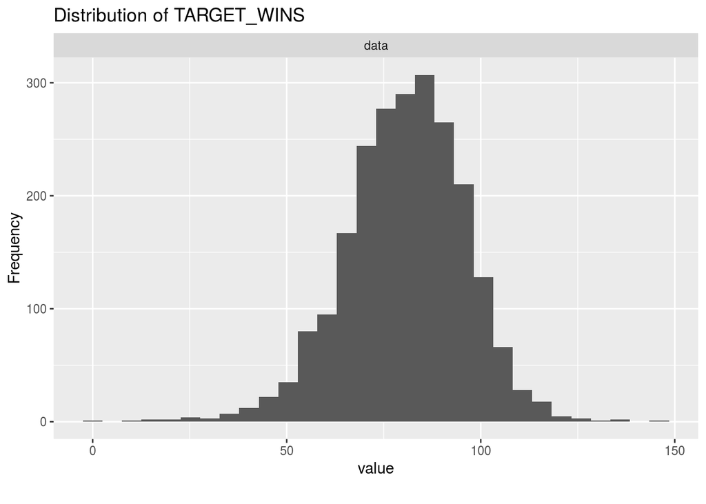

**Objective** To build a multiple linear regression model on the training data to predict *TARGET_WINS*, which is the number of wins for the team.

## Summary

Data summary

| Name | baseball_df |
| --- | --- |
| Number of rows | 2276 |
| Number of columns | 17 |
| _______________________ |  |
| Column type frequency: |  |
| numeric | 17 |
| ________________________ |  |
| Group variables | None |

**Variable type: numeric**

| skim_variable | n_missing | complete_rate | mean | sd | p0 | p25 | p50 | p75 | p100 | hist |
| --- | --- | --- | --- | --- | --- | --- | --- | --- | --- | --- |
| INDEX | 0 | 1.00 | 1268.46 | 736.35 | 1 | 630.75 | 1270.5 | 1915.50 | 2535 | ▇▇▇▇▇ |
| TARGET_WINS | 0 | 1.00 | 80.79 | 15.75 | 0 | 71.00 | 82.0 | 92.00 | 146 | ▁▁▇▅▁ |
| TEAM_BATTING_H | 0 | 1.00 | 1469.27 | 144.59 | 891 | 1383.00 | 1454.0 | 1537.25 | 2554 | ▁▇▂▁▁ |
| TEAM_BATTING_2B | 0 | 1.00 | 241.25 | 46.80 | 69 | 208.00 | 238.0 | 273.00 | 458 | ▁▆▇▂▁ |
| TEAM_BATTING_3B | 0 | 1.00 | 55.25 | 27.94 | 0 | 34.00 | 47.0 | 72.00 | 223 | ▇▇▂▁▁ |
| TEAM_BATTING_HR | 0 | 1.00 | 99.61 | 60.55 | 0 | 42.00 | 102.0 | 147.00 | 264 | ▇▆▇▅▁ |
| TEAM_BATTING_BB | 0 | 1.00 | 501.56 | 122.67 | 0 | 451.00 | 512.0 | 580.00 | 878 | ▁▁▇▇▁ |
| TEAM_BATTING_SO | 102 | 0.96 | 735.61 | 248.53 | 0 | 548.00 | 750.0 | 930.00 | 1399 | ▁▆▇▇▁ |
| TEAM_BASERUN_SB | 131 | 0.94 | 124.76 | 87.79 | 0 | 66.00 | 101.0 | 156.00 | 697 | ▇▃▁▁▁ |
| TEAM_BASERUN_CS | 772 | 0.66 | 52.80 | 22.96 | 0 | 38.00 | 49.0 | 62.00 | 201 | ▃▇▁▁▁ |
| TEAM_BATTING_HBP | 2085 | 0.08 | 59.36 | 12.97 | 29 | 50.50 | 58.0 | 67.00 | 95 | ▂▇▇▅▁ |
| TEAM_PITCHING_H | 0 | 1.00 | 1779.21 | 1406.84 | 1137 | 1419.00 | 1518.0 | 1682.50 | 30132 | ▇▁▁▁▁ |
| TEAM_PITCHING_HR | 0 | 1.00 | 105.70 | 61.30 | 0 | 50.00 | 107.0 | 150.00 | 343 | ▇▇▆▁▁ |
| TEAM_PITCHING_BB | 0 | 1.00 | 553.01 | 166.36 | 0 | 476.00 | 536.5 | 611.00 | 3645 | ▇▁▁▁▁ |
| TEAM_PITCHING_SO | 102 | 0.96 | 817.73 | 553.09 | 0 | 615.00 | 813.5 | 968.00 | 19278 | ▇▁▁▁▁ |
| TEAM_FIELDING_E | 0 | 1.00 | 246.48 | 227.77 | 65 | 127.00 | 159.0 | 249.25 | 1898 | ▇▁▁▁▁ |
| TEAM_FIELDING_DP | 286 | 0.87 | 146.39 | 26.23 | 52 | 131.00 | 149.0 | 164.00 | 228 | ▁▂▇▆▁ |

```
##      INDEX         TARGET_WINS     TEAM_BATTING_H TEAM_BATTING_2B
##  Min.   :   1.0   Min.   :  0.00   Min.   : 891   Min.   : 69.0
##  1st Qu.: 630.8   1st Qu.: 71.00   1st Qu.:1383   1st Qu.:208.0
##  Median :1270.5   Median : 82.00   Median :1454   Median :238.0
##  Mean   :1268.5   Mean   : 80.79   Mean   :1469   Mean   :241.2
##  3rd Qu.:1915.5   3rd Qu.: 92.00   3rd Qu.:1537   3rd Qu.:273.0
##  Max.   :2535.0   Max.   :146.00   Max.   :2554   Max.   :458.0
##
##  TEAM_BATTING_3B  TEAM_BATTING_HR  TEAM_BATTING_BB TEAM_BATTING_SO
##  Min.   :  0.00   Min.   :  0.00   Min.   :  0.0   Min.   :   0.0
##  1st Qu.: 34.00   1st Qu.: 42.00   1st Qu.:451.0   1st Qu.: 548.0
##  Median : 47.00   Median :102.00   Median :512.0   Median : 750.0
##  Mean   : 55.25   Mean   : 99.61   Mean   :501.6   Mean   : 735.6
##  3rd Qu.: 72.00   3rd Qu.:147.00   3rd Qu.:580.0   3rd Qu.: 930.0
##  Max.   :223.00   Max.   :264.00   Max.   :878.0   Max.   :1399.0
##                                                    NA's   :102
##  TEAM_BASERUN_SB TEAM_BASERUN_CS TEAM_BATTING_HBP TEAM_PITCHING_H
##  Min.   :  0.0   Min.   :  0.0   Min.   :29.00    Min.   : 1137
##  1st Qu.: 66.0   1st Qu.: 38.0   1st Qu.:50.50    1st Qu.: 1419
##  Median :101.0   Median : 49.0   Median :58.00    Median : 1518
##  Mean   :124.8   Mean   : 52.8   Mean   :59.36    Mean   : 1779
##  3rd Qu.:156.0   3rd Qu.: 62.0   3rd Qu.:67.00    3rd Qu.: 1682
##  Max.   :697.0   Max.   :201.0   Max.   :95.00    Max.   :30132
##  NA's   :131     NA's   :772     NA's   :2085
##  TEAM_PITCHING_HR TEAM_PITCHING_BB TEAM_PITCHING_SO  TEAM_FIELDING_E
##  Min.   :  0.0    Min.   :   0.0   Min.   :    0.0   Min.   :  65.0
##  1st Qu.: 50.0    1st Qu.: 476.0   1st Qu.:  615.0   1st Qu.: 127.0
##  Median :107.0    Median : 536.5   Median :  813.5   Median : 159.0
##  Mean   :105.7    Mean   : 553.0   Mean   :  817.7   Mean   : 246.5
##  3rd Qu.:150.0    3rd Qu.: 611.0   3rd Qu.:  968.0   3rd Qu.: 249.2
##  Max.   :343.0    Max.   :3645.0   Max.   :19278.0   Max.   :1898.0
##                                    NA's   :102
##  TEAM_FIELDING_DP
##  Min.   : 52.0
##  1st Qu.:131.0
##  Median :149.0
##  Mean   :146.4
##  3rd Qu.:164.0
##  Max.   :228.0
##  NA's   :286
```

```
## [1] "Observations per year, 1871 - 2006:"
```

```
## [1] 16.86
```

There are several variables with skewed distributions that could benefit from transformation.Additionally, there are a few variables with bi-modal distributions. Moreover, certain variables such as TEAM_BATTING_HBP have a lot of missing data (2085 out of 2276 obs.) which lowers its completion rate to about just 8%.

## Outliers

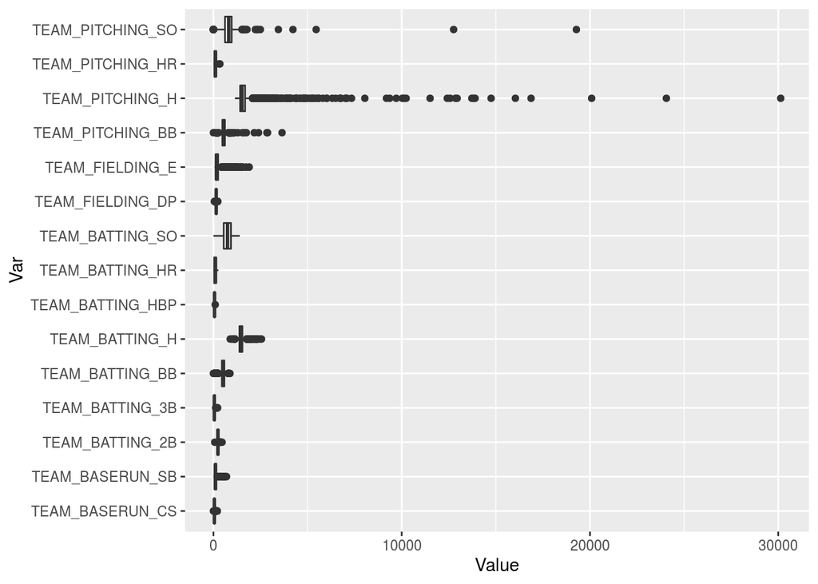

From the boxplot above, we can see that several data columns like TEAM_PITCHING_H AND TEAM_PITCHING_SO have extreme outliers. The assignment mentions that some of the season records were adjusted to match the performance during a 162-game season.

# Correlation and Collinearity

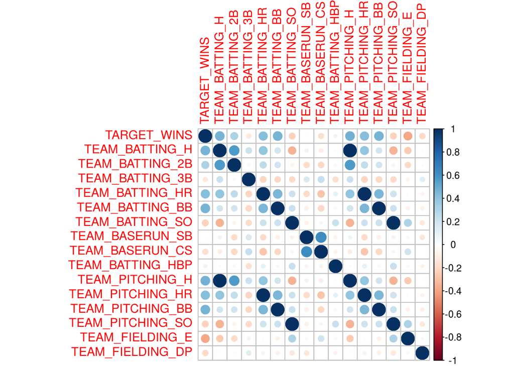

Looking at the correlation plot, there appear to be several statistically significant correlations between explanatory variables and the target.  
From an initial inspection, it appears the team should focus on getting players on base through hits or walks.Contrary to what was expected, teams can still win if the pitchers allow homeruns, hits and walks to the other team.

*Variables with Highest Positive Correlation with TARGET_WINS:*  
* TEAM_BATTING_H = 0.47 * TEAM_BATTING_HR = 0.42 * TEAM_BATTING_BB = 0.47 * TEAM_PITCHING_H = 0.47 * TEAM_PITCHING_HR = 0.42 * TEAM_PITCHING_BB = 0.47

To win more games it makes sense the team will need to make fewer errors.

Within this group, we detected collinearity between some of the variables:

*Positive Correlations between predictors*:  
* TEAM_PITCHING_H and TEAM_BATTING_H = 0.99  
* TEAM_PITCHING_HR and TEAM_BATTING_HR = 0.99  
* TEAM_PITCHING_BB and TEAM_BATTING_BB = 0.99

*Negative Correlations between predictors*:  
* TEAM_PITCHING_SO and TEAM_BATTING_H = -0.34  
* TEAM_PITCHING_SO and TEAM_PITCHING_H = -0.34

# **DATA PREPARATION**

## Missing values

In terms of missing values, there are two variables missing many observations. TEAM_BATTING_HBP is missing over 90% of its values, while TEAM_BASERUN_CS is missing just around 30%. Since TEAM_BATTING_HBP is barely complete and, deleting this variable would make sense.

The rest of the variables with missing values are: TEAM_BATTING_SO TEAM_BASERUN_SB TEAM_BASERUN_CS TEAM_FIELDING_DP TEAM_PITCHING_SO

*Multiple Imputation*

We will also attempt multiple imputation on the original dataset.Multiple imputation assumes normailty of data so let’s check for skewness once again among the dataset:

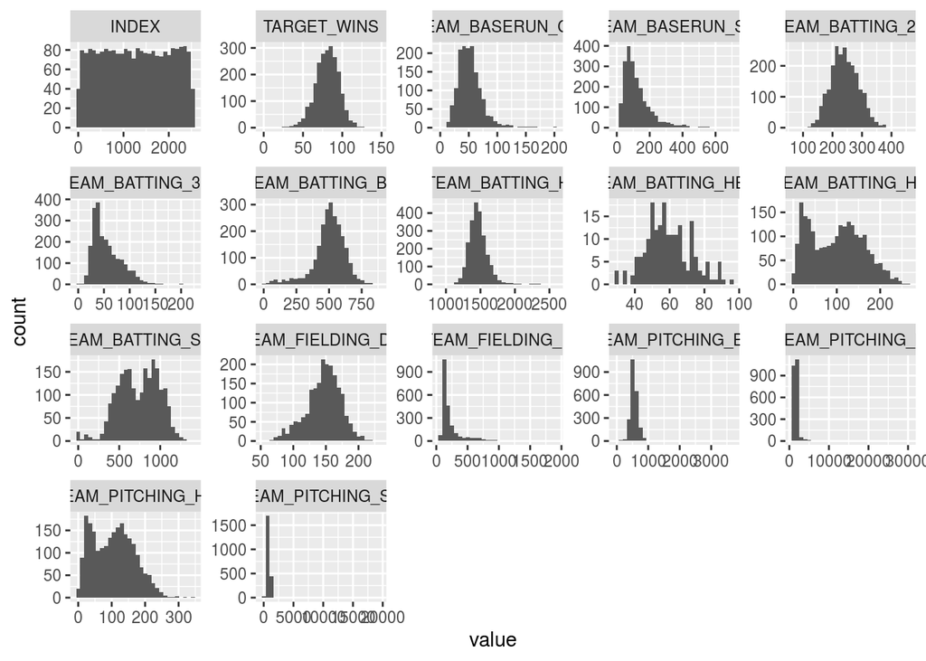

It seems like TEAM_BASERUN_SB, TEAM_PITCHING_SO and TEAM_FIELDING_E are skewed. Let’s confirm this using the skewness function. Anything that has a skewness above 1 is thought to be highly skewed.

```
## [1] 22.17455
```

```
## [1] 1.972414
```

```
## [1] 2.990466
```

Let’s log transform these variables prior to multiple imputation.

Now that we have log transformed most of the variable and all our data are numeric, let’s impute the data.

[output not shown]

[output cut: 518 more lines]

Notice that we have imputed the entire dataset.This is because, although certain variables do not have any missing data, they maybe helpful in predicting missing values in the variables that do have them (Faraway, 2014)

# **BUILDMODELS**

## Model 1

We will build the initial models on the original dataset first (prior to multiple imputation) for comparison purposes.

We want to try creating a simple model with fewer predictors to see how it performs compared to our other models. To start, we chose a few variables that were highly positively and negatively correlated with TARGET_WINS.

From there we removed multiple predictors at once. To do this we need to construct a null hypothesis test which states that removing the variables doesn’t make a better model. We construct a F-test and compare both versions of the model. If the p-value is under 0.05 we reject the null hypothesis, which indicates our new model isn’t different than the first model. If the p-value is greater than 0.05, the model isn’t better with those variables, so we will remove them. The simpler the model the better.

To determine which variables we removed,we chose the variable that was not proving to be significant in the linear regression (where the p-value was greater than 0.05). While this doesn’t mean the variable itself isn’t signficant, it means the variable alongside the other combination of variables in the model is not significant.

```
##
## Call:
## lm(formula = TARGET_WINS ~ TEAM_BATTING_H + TEAM_BATTING_HR +
##     TEAM_BATTING_BB + TEAM_BATTING_SO + TEAM_PITCHING_H + TEAM_PITCHING_HR +
##     TEAM_PITCHING_BB + TEAM_PITCHING_SO + TEAM_FIELDING_E + TEAM_FIELDING_DP,
##     data = baseball_df_fix)
##
## Residuals:
##     Min      1Q  Median      3Q     Max
## -44.378  -7.898   0.200   7.831  39.906
##
## Coefficients:
##                   Estimate Std. Error t value Pr(>|t|)
## (Intercept)      54.808616   5.980591   9.164  < 2e-16 ***
## TEAM_BATTING_H    0.016475   0.004154   3.966 7.58e-05 ***
## TEAM_BATTING_HR   0.266831   0.057338   4.654 3.49e-06 ***
## TEAM_BATTING_BB   0.042737   0.019148   2.232 0.025733 *
## TEAM_BATTING_SO  -0.028802   0.009339  -3.084 0.002071 **
## TEAM_PITCHING_H   0.016827   0.002304   7.303 4.13e-13 ***
## TEAM_PITCHING_HR -0.207321   0.054299  -3.818 0.000139 ***
## TEAM_PITCHING_BB -0.010049   0.017800  -0.565 0.572447
## TEAM_PITCHING_SO  0.011148   0.008467   1.317 0.188131
## TEAM_FIELDING_E  -0.057509   0.005488 -10.478  < 2e-16 ***
## TEAM_FIELDING_DP -0.158032   0.012962 -12.192  < 2e-16 ***
## ---
## Signif. codes:  0 '***' 0.001 '**' 0.01 '*' 0.05 '.' 0.1 ' ' 1
##
## Residual standard error: 11.42 on 1877 degrees of freedom
##   (388 observations deleted due to missingness)
## Multiple R-squared:  0.2991, Adjusted R-squared:  0.2954
## F-statistic:  80.1 on 10 and 1877 DF,  p-value: < 2.2e-16
```

```
##
## Call:
## lm(formula = TARGET_WINS ~ TEAM_BATTING_H + TEAM_BATTING_HR +
##     TEAM_BATTING_BB + TEAM_BATTING_SO + TEAM_PITCHING_H + TEAM_PITCHING_HR +
##     TEAM_FIELDING_E + TEAM_FIELDING_DP, data = baseball_df_fix)
##
## Residuals:
##     Min      1Q  Median      3Q     Max
## -44.327  -7.799   0.209   7.875  40.210
##
## Coefficients:
##                   Estimate Std. Error t value Pr(>|t|)
## (Intercept)      54.574784   5.954596   9.165  < 2e-16 ***
## TEAM_BATTING_H    0.015205   0.003802   4.000 6.59e-05 ***
## TEAM_BATTING_HR   0.243859   0.032695   7.459 1.33e-13 ***
## TEAM_BATTING_BB   0.032029   0.003446   9.294  < 2e-16 ***
## TEAM_BATTING_SO  -0.016874   0.002207  -7.646 3.29e-14 ***
## TEAM_PITCHING_H   0.017731   0.001833   9.671  < 2e-16 ***
## TEAM_PITCHING_HR -0.184892   0.031112  -5.943 3.33e-09 ***
## TEAM_FIELDING_E  -0.055757   0.005293 -10.535  < 2e-16 ***
## TEAM_FIELDING_DP -0.156392   0.012867 -12.155  < 2e-16 ***
## ---
## Signif. codes:  0 '***' 0.001 '**' 0.01 '*' 0.05 '.' 0.1 ' ' 1
##
## Residual standard error: 11.42 on 1879 degrees of freedom
##   (388 observations deleted due to missingness)
## Multiple R-squared:  0.2984, Adjusted R-squared:  0.2955
## F-statistic: 99.92 on 8 and 1879 DF,  p-value: < 2.2e-16
```

```
## Analysis of Variance Table
##
## Model 1: TARGET_WINS ~ TEAM_BATTING_H + TEAM_BATTING_HR + TEAM_BATTING_BB +
##     TEAM_BATTING_SO + TEAM_PITCHING_H + TEAM_PITCHING_HR + TEAM_PITCHING_BB +
##     TEAM_PITCHING_SO + TEAM_FIELDING_E + TEAM_FIELDING_DP
## Model 2: TARGET_WINS ~ TEAM_BATTING_H + TEAM_BATTING_HR + TEAM_BATTING_BB +
##     TEAM_BATTING_SO + TEAM_PITCHING_H + TEAM_PITCHING_HR + TEAM_FIELDING_E +
##     TEAM_FIELDING_DP
##   Res.Df    RSS Df Sum of Sq      F Pr(>F)
## 1   1877 244715
## 2   1879 244944 -2   -229.32 0.8794 0.4152
```

- Took the log of TEAM_PITCHING_H it’s relationship to TARGET_WINS more linear

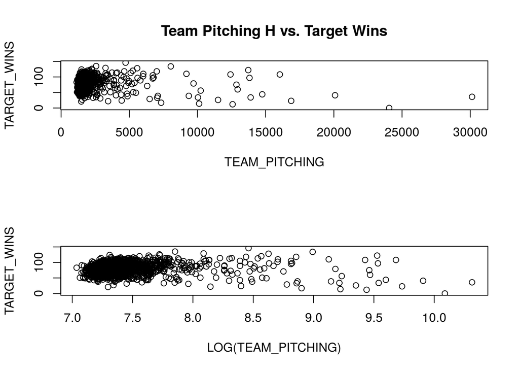

```
##
## Call:
## lm(formula = TARGET_WINS ~ TEAM_BATTING_H + TEAM_BATTING_HR +
##     TEAM_BATTING_BB + TEAM_BATTING_SO + log(TEAM_PITCHING_H) +
##     TEAM_PITCHING_HR + TEAM_FIELDING_E + TEAM_FIELDING_DP, data = baseball_df_fix)
##
## Residuals:
##     Min      1Q  Median      3Q     Max
## -43.996  -7.809   0.122   7.874  37.186
##
## Coefficients:
##                        Estimate Std. Error t value Pr(>|t|)
## (Intercept)          -3.017e+02  3.377e+01  -8.933  < 2e-16 ***
## TEAM_BATTING_H       -1.227e-03  4.861e-03  -0.252    0.801
## TEAM_BATTING_HR       3.815e-01  4.108e-02   9.286  < 2e-16 ***
## TEAM_BATTING_BB       3.238e-02  3.437e-03   9.421  < 2e-16 ***
## TEAM_BATTING_SO      -1.557e-02  2.183e-03  -7.132 1.40e-12 ***
## log(TEAM_PITCHING_H)  5.567e+01  5.435e+00  10.243  < 2e-16 ***
## TEAM_PITCHING_HR     -3.208e-01  3.984e-02  -8.051 1.44e-15 ***
## TEAM_FIELDING_E      -6.390e-02  5.740e-03 -11.133  < 2e-16 ***
## TEAM_FIELDING_DP     -1.564e-01  1.283e-02 -12.194  < 2e-16 ***
## ---
## Signif. codes:  0 '***' 0.001 '**' 0.01 '*' 0.05 '.' 0.1 ' ' 1
##
## Residual standard error: 11.38 on 1879 degrees of freedom
##   (388 observations deleted due to missingness)
## Multiple R-squared:  0.3025, Adjusted R-squared:  0.2995
## F-statistic: 101.8 on 8 and 1879 DF,  p-value: < 2.2e-16
```

- Remove TEAM_BATTING_H

```
##
## Call:
## lm(formula = TARGET_WINS ~ TEAM_BATTING_HR + TEAM_BATTING_BB +
##     TEAM_BATTING_SO + log(TEAM_PITCHING_H) + TEAM_PITCHING_HR +
##     TEAM_FIELDING_E + TEAM_FIELDING_DP, data = baseball_df_fix)
##
## Residuals:
##     Min      1Q  Median      3Q     Max
## -43.997  -7.787   0.124   7.878  37.288
##
## Coefficients:
##                        Estimate Std. Error t value Pr(>|t|)
## (Intercept)          -2.957e+02  2.409e+01 -12.274  < 2e-16 ***
## TEAM_BATTING_HR       3.747e-01  3.103e-02  12.073  < 2e-16 ***
## TEAM_BATTING_BB       3.231e-02  3.423e-03   9.438  < 2e-16 ***
## TEAM_BATTING_SO      -1.535e-02  1.994e-03  -7.696 2.25e-14 ***
## log(TEAM_PITCHING_H)  5.458e+01  3.284e+00  16.618  < 2e-16 ***
## TEAM_PITCHING_HR     -3.146e-01  3.134e-02 -10.037  < 2e-16 ***
## TEAM_FIELDING_E      -6.300e-02  4.494e-03 -14.018  < 2e-16 ***
## TEAM_FIELDING_DP     -1.564e-01  1.282e-02 -12.194  < 2e-16 ***
## ---
## Signif. codes:  0 '***' 0.001 '**' 0.01 '*' 0.05 '.' 0.1 ' ' 1
##
## Residual standard error: 11.38 on 1880 degrees of freedom
##   (388 observations deleted due to missingness)
## Multiple R-squared:  0.3024, Adjusted R-squared:  0.2998
## F-statistic: 116.4 on 7 and 1880 DF,  p-value: < 2.2e-16
```

```
## Analysis of Variance Table
##
## Model 1: TARGET_WINS ~ TEAM_BATTING_H + TEAM_BATTING_HR + TEAM_BATTING_BB +
##     TEAM_BATTING_SO + log(TEAM_PITCHING_H) + TEAM_PITCHING_HR +
##     TEAM_FIELDING_E + TEAM_FIELDING_DP
## Model 2: TARGET_WINS ~ TEAM_BATTING_HR + TEAM_BATTING_BB + TEAM_BATTING_SO +
##     log(TEAM_PITCHING_H) + TEAM_PITCHING_HR + TEAM_FIELDING_E +
##     TEAM_FIELDING_DP
##   Res.Df    RSS Df Sum of Sq      F Pr(>F)
## 1   1879 243539
## 2   1880 243547 -1   -8.2595 0.0637 0.8007
```

## Model 2

```
##
## Call:
## lm(formula = TARGET_WINS ~ . - INDEX + log(TEAM_FIELDING_E) +
##     log(TEAM_PITCHING_BB) - TEAM_PITCHING_H - TEAM_BATTING_BB -
##     TEAM_PITCHING_HR - TEAM_PITCHING_BB - TEAM_FIELDING_E + log(TEAM_FIELDING_E) +
##     TEAM_BATTING_3B:TEAM_BATTING_HR + TEAM_BATTING_2B:TEAM_BATTING_HR +
##     TEAM_BATTING_H:TEAM_BATTING_HR + TEAM_BATTING_H:TEAM_BATTING_3B -
##     TEAM_BATTING_3B - TEAM_BATTING_SO - TEAM_BATTING_2B - TEAM_BATTING_BB -
##     TEAM_BATTING_HR - TEAM_BATTING_H - TEAM_BATTING_HR - TEAM_PITCHING_HR -
##     TEAM_BATTING_HBP - TEAM_FIELDING_DP - TEAM_PITCHING_SO -
##     TEAM_BASERUN_SB - TEAM_BASERUN_CS, data = baseball_df_fix)
##
## Residuals:
##      Min       1Q   Median       3Q      Max
## -20.8825  -5.7136  -0.1331   6.3792  22.9085
##
## Coefficients:
##                                   Estimate Std. Error t value Pr(>|t|)
## (Intercept)                      2.143e+00  4.139e+01   0.052  0.95876
## log(TEAM_FIELDING_E)            -2.392e+01  4.325e+00  -5.530 1.09e-07 ***
## log(TEAM_PITCHING_BB)            2.508e+01  5.440e+00   4.611 7.49e-06 ***
## TEAM_BATTING_3B:TEAM_BATTING_HR -4.306e-03  1.427e-03  -3.018  0.00290 **
## TEAM_BATTING_2B:TEAM_BATTING_HR -3.449e-05  1.703e-04  -0.203  0.83971
## TEAM_BATTING_H:TEAM_BATTING_HR   1.434e-04  4.261e-05   3.366  0.00093 ***
## TEAM_BATTING_H:TEAM_BATTING_3B   4.332e-04  1.556e-04   2.783  0.00594 **
## ---
## Signif. codes:  0 '***' 0.001 '**' 0.01 '*' 0.05 '.' 0.1 ' ' 1
##
## Residual standard error: 9.06 on 184 degrees of freedom
##   (2085 observations deleted due to missingness)
## Multiple R-squared:  0.4584, Adjusted R-squared:  0.4408
## F-statistic: 25.96 on 6 and 184 DF,  p-value: < 2.2e-16
```

The R-squared statistic indicates that this model predicts about half of the variation in wins with the included features. The model is statistically significant at p<.05, however the F-Statistic seems to have fallen quite a bit from the initial model.

## Model 3

This model takes into account the imputed dataset and models TARGET_WINS against all variables present in the dataset except for INDEX (since this is the id variables and had a very weak negative association with TARGET_WINS)

```
##
## Call:
## lm(formula = TARGET_WINS ~ . - INDEX, data = missmod$imputations[[i]])
##
## Residuals:
##     Min      1Q  Median      3Q     Max
## -57.105  -7.879  -0.086   8.055  43.164
##
## Coefficients:
##                    Estimate Std. Error t value Pr(>|t|)
## (Intercept)      -23.836016  28.445175  -0.838 0.402140
## TEAM_BATTING_H     0.153522   0.063906   2.402 0.016371 *
## TEAM_BATTING_2B   -0.033816   0.008848  -3.822 0.000136 ***
## TEAM_BATTING_3B    0.079610   0.016635   4.786 1.82e-06 ***
## TEAM_BATTING_HR    0.368897   0.165439   2.230 0.025858 *
## TEAM_BATTING_BB   -0.344387   0.232176  -1.483 0.138134
## TEAM_BATTING_SO   -0.050566   0.006119  -8.265 2.36e-16 ***
## TEAM_BASERUN_SB    3.987815   0.771488   5.169 2.56e-07 ***
## TEAM_BASERUN_CS    0.074637   0.017358   4.300 1.78e-05 ***
## TEAM_BATTING_HBP   0.033273   0.021003   1.584 0.113289
## TEAM_PITCHING_H   -0.103930   0.064977  -1.599 0.109852
## TEAM_PITCHING_HR  -0.291142   0.165017  -1.764 0.077813 .
## TEAM_PITCHING_BB   0.363834   0.232686   1.564 0.118045
## TEAM_PITCHING_SO  23.548478   4.552359   5.173 2.51e-07 ***
## TEAM_FIELDING_E  -19.679926   1.056598 -18.626  < 2e-16 ***
## TEAM_FIELDING_DP  -0.159912   0.012724 -12.567  < 2e-16 ***
## ---
## Signif. codes:  0 '***' 0.001 '**' 0.01 '*' 0.05 '.' 0.1 ' ' 1
##
## Residual standard error: 12.14 on 2260 degrees of freedom
## Multiple R-squared:  0.4096, Adjusted R-squared:  0.4057
## F-statistic: 104.5 on 15 and 2260 DF,  p-value: < 2.2e-16
```

The model above is for all of the predictors in the dataset(except for Index). It is statistically significant at p<.05 and the adjusted r squared for the model is 0.405, which means that about 40.5% of the variance in the dataset is explained by the model.

## Model 4

We will modify the model a bit and eliminate variables that we had previously flagged for multicollinearity such as TEAM_PITCHING_HR,TEAM_PITCHING_BB and TEAM_PITCHING_H. This is important since multicollinearity can significantly reduce model performance.Out of these predictors, TEAM_PITCHING_H also had extreme outliers, along with TEAM_PITCHING_SO. Since the r-square is computed using the mean, variables with outliers will throw off this value. Therefore, although we have transformed TEAM_PITCHING_SO, it maybe best to still remove this variable from the model.

```
##
## Call:
## lm(formula = TARGET_WINS ~ . - INDEX - TEAM_PITCHING_HR - TEAM_PITCHING_BB -
##     TEAM_PITCHING_H - TEAM_PITCHING_SO, data = missmod$imputations[[i]])
##
## Residuals:
##     Min      1Q  Median      3Q     Max
## -54.237  -7.926  -0.228   7.878  46.116
##
## Coefficients:
##                    Estimate Std. Error t value Pr(>|t|)
## (Intercept)       1.110e+02  7.640e+00  14.532  < 2e-16 ***
## TEAM_BATTING_H    4.342e-02  3.479e-03  12.480  < 2e-16 ***
## TEAM_BATTING_2B  -2.566e-02  8.537e-03  -3.006 0.002678 **
## TEAM_BATTING_3B   5.995e-02  1.616e-02   3.709 0.000213 ***
## TEAM_BATTING_HR   8.397e-02  9.464e-03   8.872  < 2e-16 ***
## TEAM_BATTING_BB   1.501e-02  2.939e-03   5.106 3.56e-07 ***
## TEAM_BATTING_SO  -2.028e-02  2.310e-03  -8.781  < 2e-16 ***
## TEAM_BASERUN_SB   3.505e+00  7.579e-01   4.624 3.97e-06 ***
## TEAM_BASERUN_CS   9.757e-02  1.677e-02   5.819 6.74e-09 ***
## TEAM_BATTING_HBP -7.407e-05  1.069e-04  -0.693 0.488362
## TEAM_FIELDING_E  -1.770e+01  9.918e-01 -17.849  < 2e-16 ***
## TEAM_FIELDING_DP -1.576e-01  1.277e-02 -12.340  < 2e-16 ***
## ---
## Signif. codes:  0 '***' 0.001 '**' 0.01 '*' 0.05 '.' 0.1 ' ' 1
##
## Residual standard error: 12.26 on 2264 degrees of freedom
## Multiple R-squared:  0.3968, Adjusted R-squared:  0.3938
## F-statistic: 135.4 on 11 and 2264 DF,  p-value: < 2.2e-16
```

After removing variables that we had previously flagged for multicollinearity and outliers, we can see that the adjusted r-squared for the model drops a bit. However the F-Statistic seems to have improved.

## Model 5

```
##
## Call:
## lm(formula = TARGET_WINS ~ . - INDEX - TEAM_PITCHING_HR - TEAM_PITCHING_BB -
##     TEAM_PITCHING_H - TEAM_PITCHING_SO + (TEAM_BATTING_H * TEAM_BATTING_2B +
##     TEAM_BATTING_H * TEAM_BATTING_3B + TEAM_BATTING_H * TEAM_BATTING_HR),
##     data = missmod$imputations[[i]])
##
## Residuals:
##     Min      1Q  Median      3Q     Max
## -54.645  -7.961  -0.071   7.958  53.271
##
## Coefficients:
##                                  Estimate Std. Error t value Pr(>|t|)
## (Intercept)                     1.181e+02  1.352e+01   8.734  < 2e-16 ***
## TEAM_BATTING_H                  3.572e-02  8.336e-03   4.285 1.91e-05 ***
## TEAM_BATTING_2B                -1.802e-01  5.069e-02  -3.555 0.000385 ***
## TEAM_BATTING_3B                 2.834e-01  9.183e-02   3.086 0.002052 **
## TEAM_BATTING_HR                 4.098e-01  6.257e-02   6.550 7.10e-11 ***
## TEAM_BATTING_BB                 1.596e-02  2.930e-03   5.448 5.64e-08 ***
## TEAM_BATTING_SO                -2.250e-02  2.349e-03  -9.580  < 2e-16 ***
## TEAM_BASERUN_SB                 3.820e+00  7.630e-01   5.006 5.97e-07 ***
## TEAM_BASERUN_CS                 1.013e-01  1.695e-02   5.978 2.62e-09 ***
## TEAM_BATTING_HBP               -9.007e-05  1.084e-04  -0.831 0.405920
## TEAM_FIELDING_E                -1.778e+01  9.863e-01 -18.029  < 2e-16 ***
## TEAM_FIELDING_DP               -1.561e-01  1.274e-02 -12.252  < 2e-16 ***
## TEAM_BATTING_H:TEAM_BATTING_2B  1.105e-04  3.377e-05   3.272 0.001083 **
## TEAM_BATTING_H:TEAM_BATTING_3B -1.431e-04  5.800e-05  -2.468 0.013673 *
## TEAM_BATTING_H:TEAM_BATTING_HR -2.143e-04  4.088e-05  -5.242 1.74e-07 ***
## ---
## Signif. codes:  0 '***' 0.001 '**' 0.01 '*' 0.05 '.' 0.1 ' ' 1
##
## Residual standard error: 12.19 on 2261 degrees of freedom
## Multiple R-squared:  0.4047, Adjusted R-squared:  0.4011
## F-statistic: 109.8 on 14 and 2261 DF,  p-value: < 2.2e-16
```

After adding the interaction effects, it seems that out adjusted r-sqaured has gone up to 0.40 (model explains 40% of the variance in the data). The model is statistically significant at p<0.05.

# **SELECT MODELS**

## Diagnostics

We will look at the residual plots and model performance statistics (MSE and RMSE) for each of the models.

*Model 1*

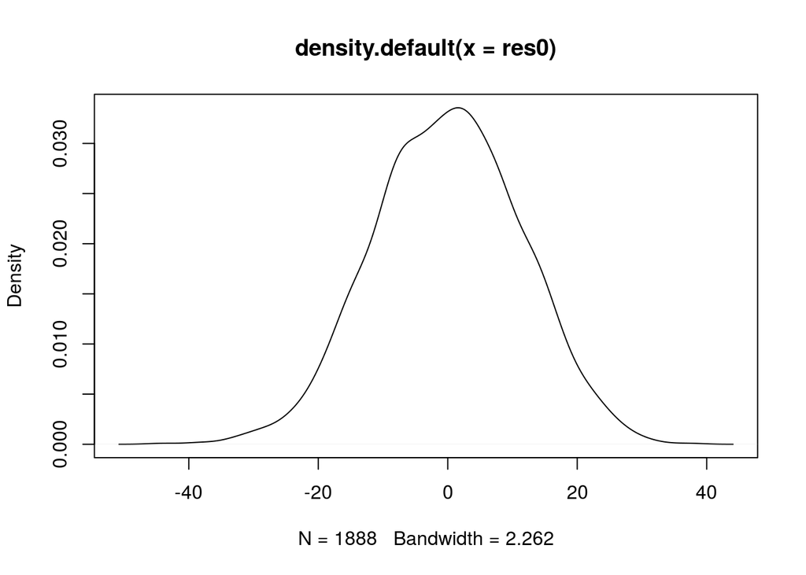

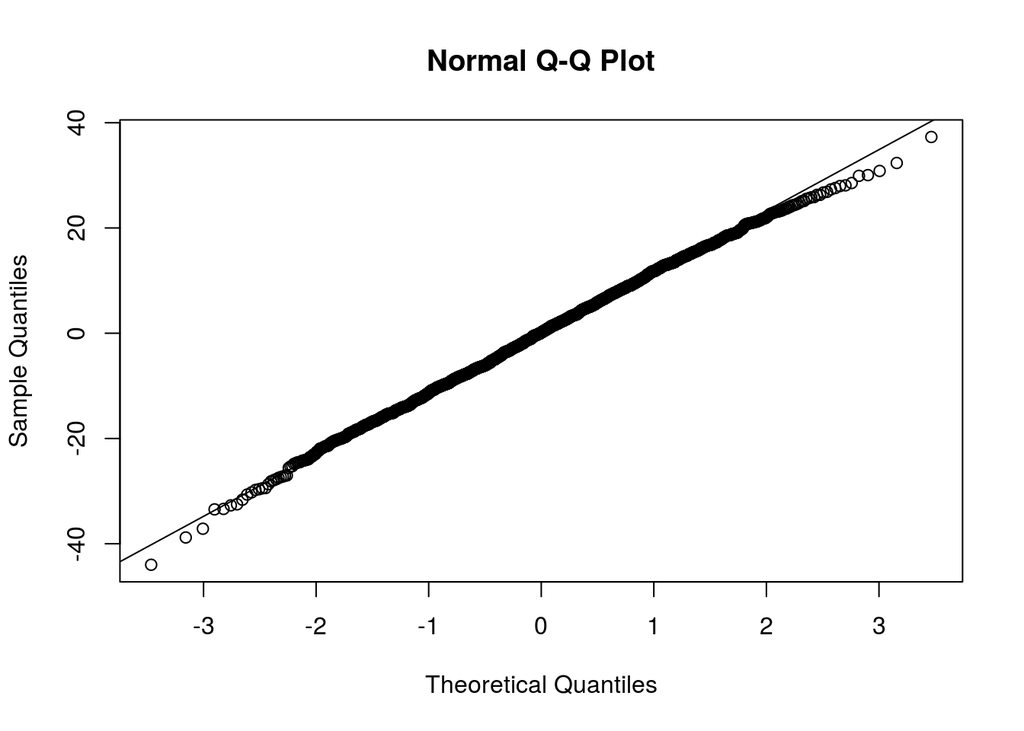

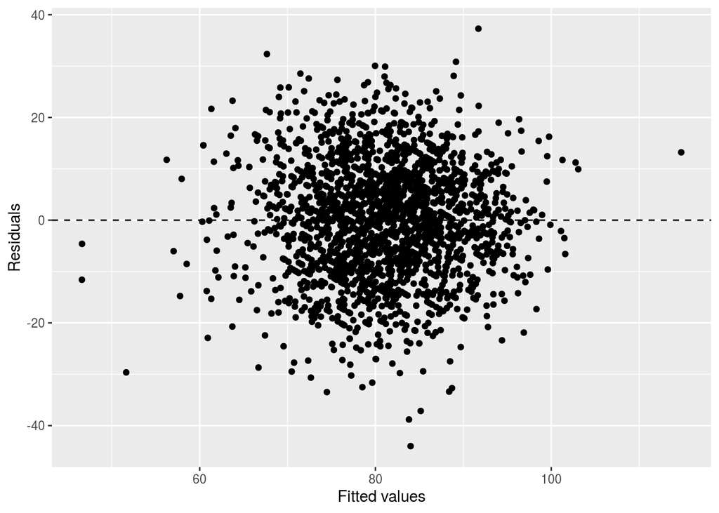

```
## [1] "Mean Squared Error: 128.997300425331"
```

```
## [1] "Root MSE: 11.3576978488306"
```

*Model 2*

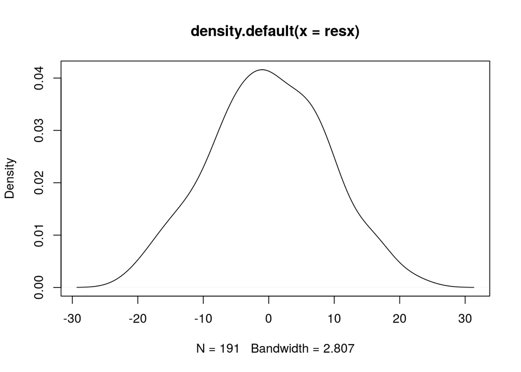

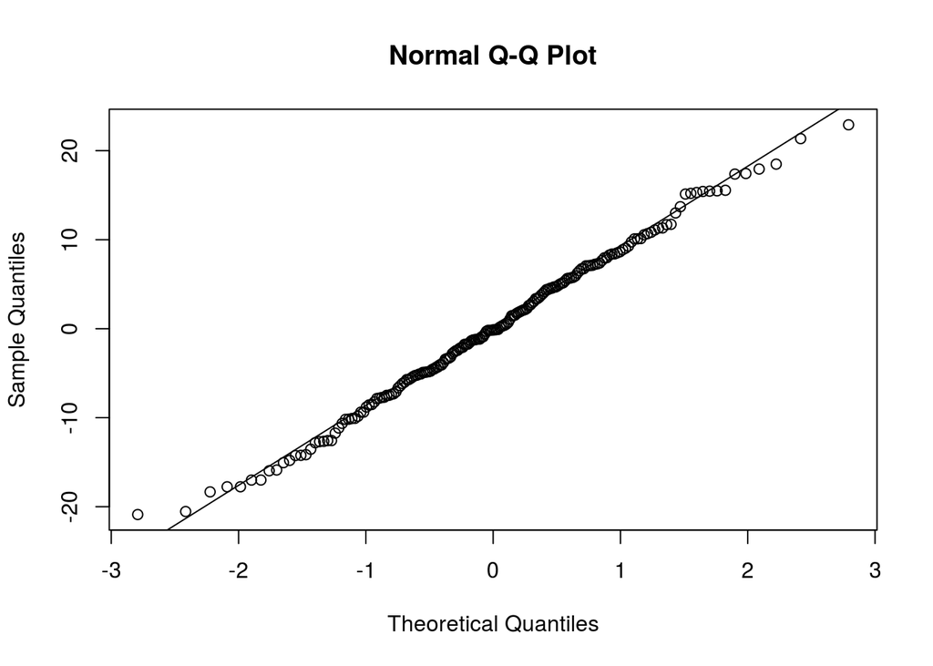

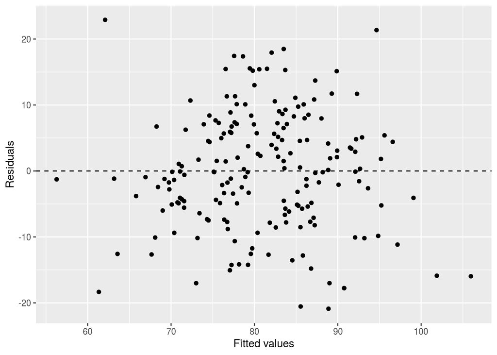

```
## [1] "Mean Squared Error: 79.0711797402695"
```

```
## [1] "Root MSE: 8.8921976890007"
```

*Model 3*

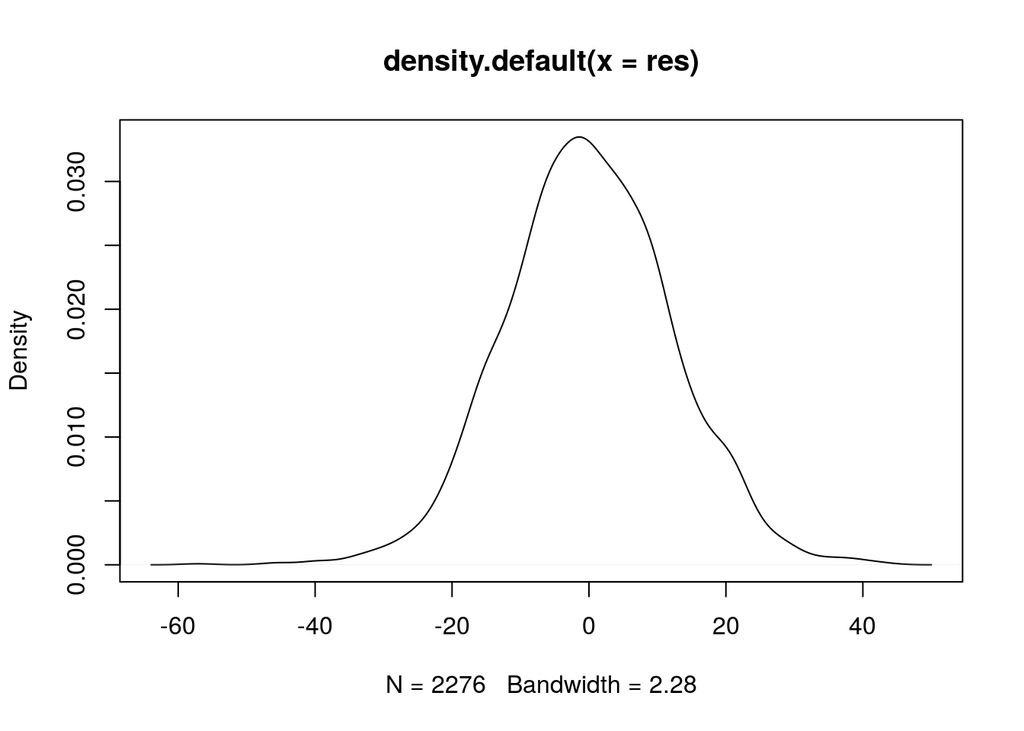

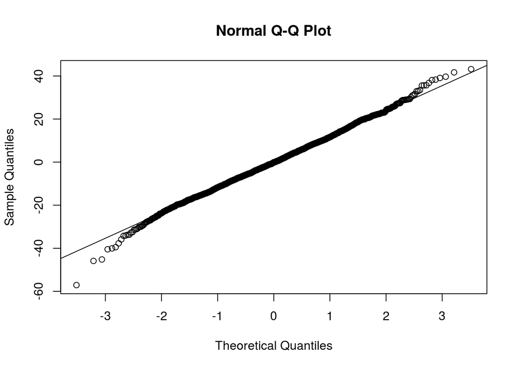

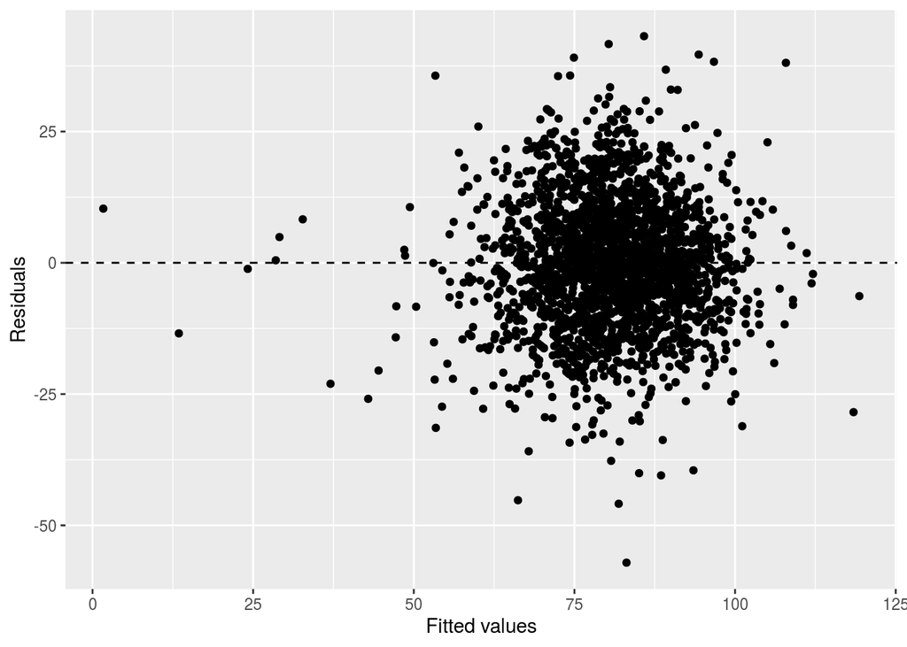

```
## [1] "Mean Squared Error: 146.432480093758"
```

```
## [1] "Root MSE: 12.1009288938395"
```

*Model 4*

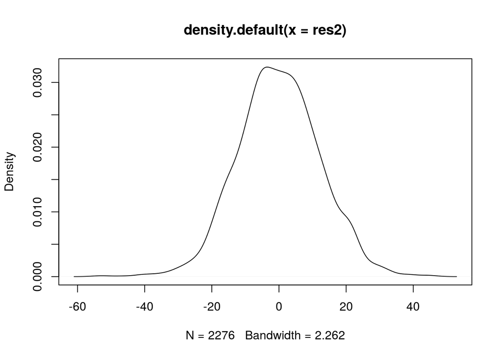

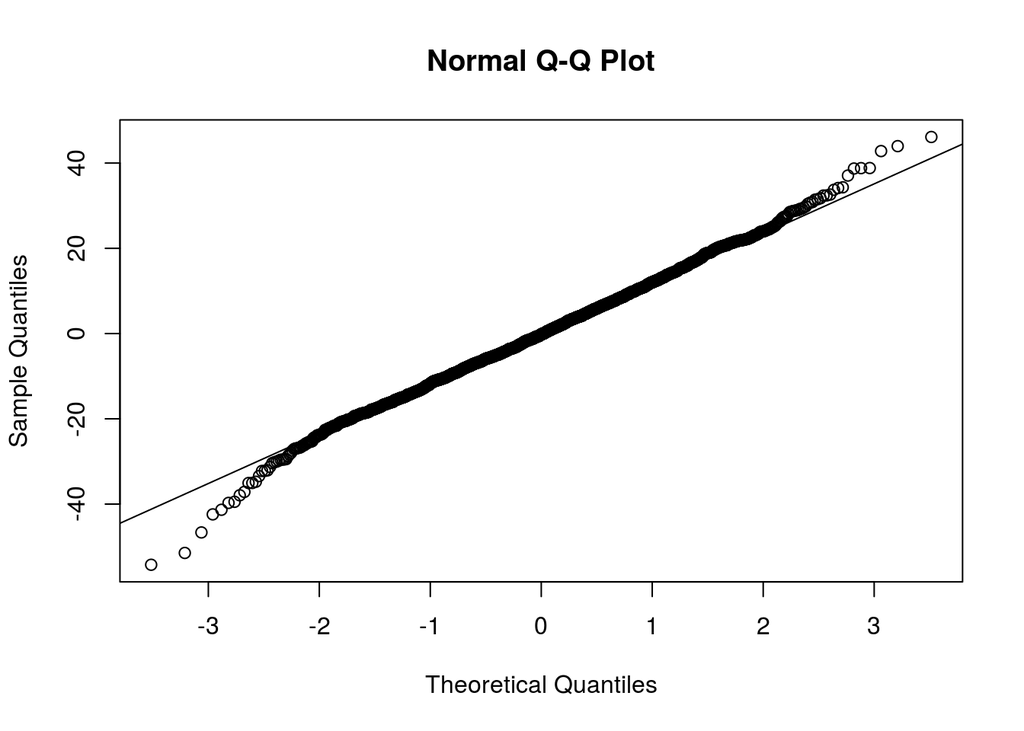

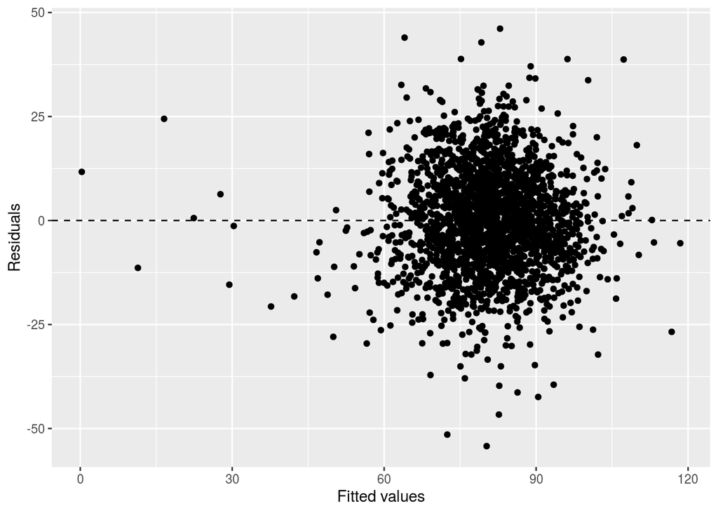

```
## [1] "Mean Squared Error: 149.617687432938"
```

```
## [1] "Root MSE: 12.2318309109036"
```

*Model 5*

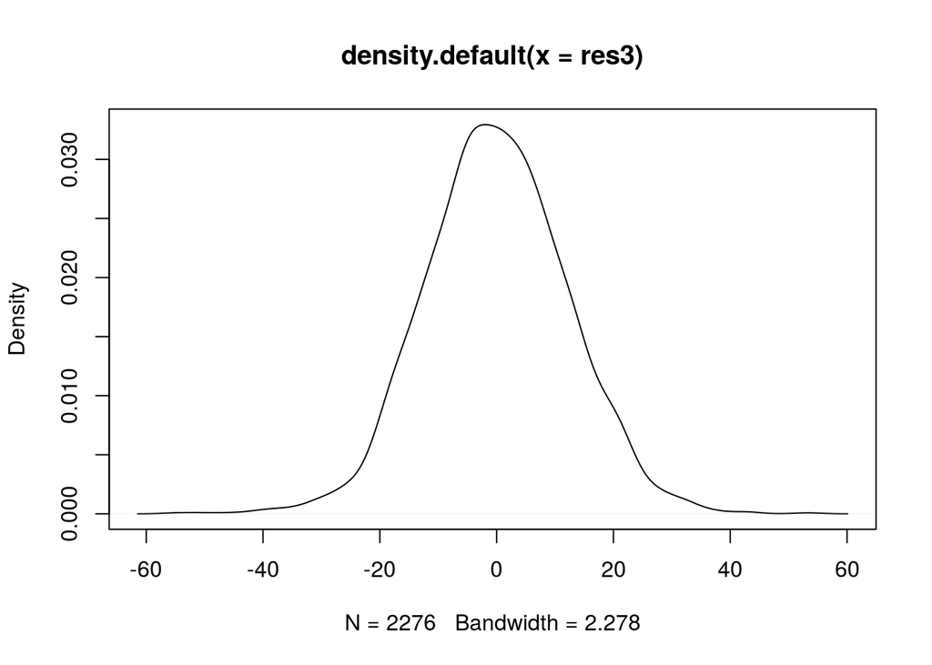

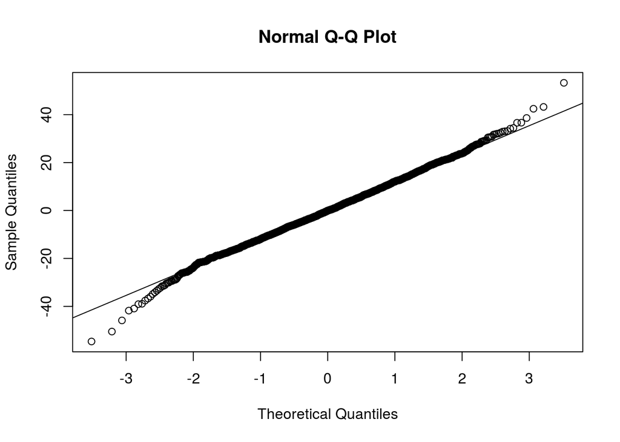

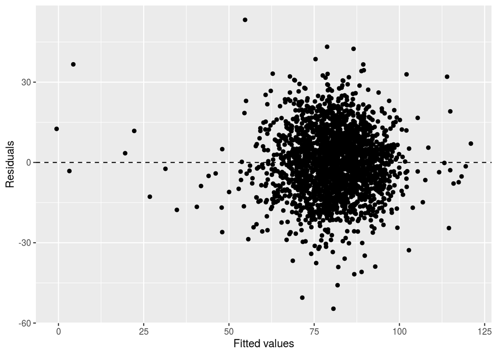

```
## [1] "Mean Squared Error: 147.636505909219"
```

```
## [1] "Root MSE: 12.1505763611945"
```

The diagnostic plots illustrate that our residuals for all 5 models are normally distributed. However, in terms of the residual abline plot, Model 2’s residual plot seems the best compared to the other 4, which seem to have a pattern to them.In addition, Model 2 also had the lowest MSE/RMSE and highest adjusted R^2 (0.44)

Therefore, *Model 2* is the best model thus far. We will further test out this model on the evaluation dataset to see if this hold.

# **FURTHER EVALUATION**

```
##            INDEX   TEAM_BATTING_H  TEAM_BATTING_2B  TEAM_BATTING_3B
##             0.00             0.00             0.00             0.00
##  TEAM_BATTING_HR  TEAM_BATTING_BB  TEAM_BATTING_SO  TEAM_BASERUN_SB
##             0.00             0.00             6.95             5.02
##  TEAM_BASERUN_CS TEAM_BATTING_HBP  TEAM_PITCHING_H TEAM_PITCHING_HR
##            33.59            92.66             0.00             0.00
## TEAM_PITCHING_BB TEAM_PITCHING_SO  TEAM_FIELDING_E TEAM_FIELDING_DP
##             0.00             6.95             0.00            11.97
```

The prediction data also has missing values, which are approximately the same as the training data.

We will run our selected model on the evaluation dataset and look at the summary.

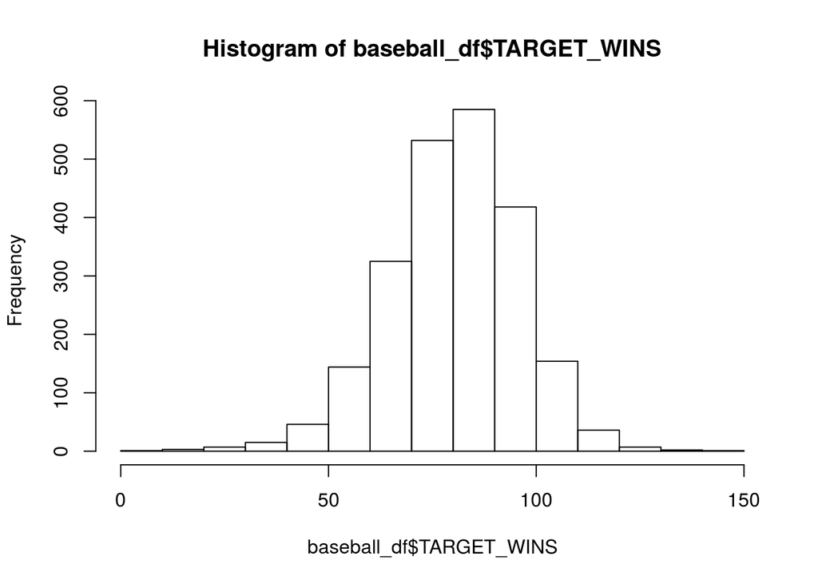

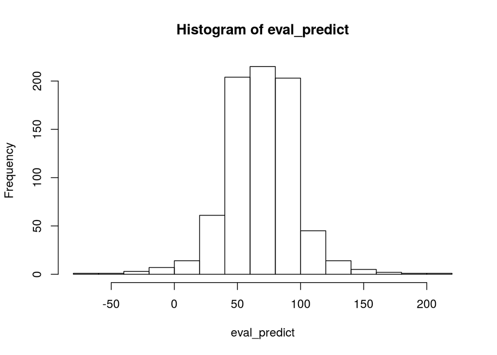

```
##       fit              lwr              upr
##  Min.   :-34.51   Min.   :-65.85   Min.   : -3.161
##  1st Qu.: 62.43   1st Qu.: 38.50   1st Qu.: 83.060
##  Median : 71.55   Median : 50.38   Median : 91.999
##  Mean   : 69.32   Mean   : 44.78   Mean   : 93.867
##  3rd Qu.: 78.39   3rd Qu.: 56.34   3rd Qu.: 99.615
##  Max.   :127.32   Max.   : 71.53   Max.   :206.949
```

```
## [1] 27.97456
```

```
##    Min. 1st Qu.  Median    Mean 3rd Qu.    Max.
##    0.00   71.00   82.00   80.79   92.00  146.00
```

```
## [1] 15.75215
```

Here are the predicted values for Target Wins, based on our model for the teams in the evaluation dataset.

Predicted Target Wins

| INDEX | TEAM_BATTING_H | TEAM_BATTING_2B | TEAM_BATTING_3B | TEAM_BATTING_HR | TEAM_BATTING_BB | TEAM_BATTING_SO | TEAM_BASERUN_SB | TEAM_BASERUN_CS | TEAM_BATTING_HBP | TEAM_PITCHING_H | TEAM_PITCHING_HR | TEAM_PITCHING_BB | TEAM_PITCHING_SO | TEAM_FIELDING_E | TEAM_FIELDING_DP | TARGET_WINS |
| --- | --- | --- | --- | --- | --- | --- | --- | --- | --- | --- | --- | --- | --- | --- | --- | --- |
| 9 | 1209 | 170 | 33 | 83 | 447 | 1080 | 62 | 50 | NA | 1209 | 83 | 447 | 1080 | 140 | 156 | 56 |
| 10 | 1221 | 151 | 29 | 88 | 516 | 929 | 54 | 39 | NA | 1221 | 88 | 516 | 929 | 135 | 164 | 61 |
| 14 | 1395 | 183 | 29 | 93 | 509 | 816 | 59 | 47 | NA | 1395 | 93 | 509 | 816 | 156 | 153 | 62 |
| 47 | 1539 | 309 | 29 | 159 | 486 | 914 | 148 | 57 | 42 | 1539 | 159 | 486 | 914 | 124 | 154 | 75 |
| 60 | 1445 | 203 | 68 | 5 | 95 | 416 | NA | NA | NA | 3902 | 14 | 257 | 1123 | 616 | 130 | 30 |
| 63 | 1431 | 236 | 53 | 10 | 215 | 377 | NA | NA | NA | 2793 | 20 | 420 | 736 | 572 | 105 | 34 |
| 74 | 1430 | 219 | 55 | 37 | 568 | 527 | 365 | NA | NA | 1544 | 40 | 613 | 569 | 490 | NA | 48 |
| 83 | 1385 | 158 | 42 | 33 | 356 | 609 | 185 | NA | NA | 1626 | 39 | 418 | 715 | 328 | 104 | 41 |
| 98 | 1259 | 177 | 78 | 23 | 466 | 689 | 150 | NA | NA | 1342 | 25 | 497 | 734 | 226 | 132 | 67 |
| 120 | 1397 | 212 | 42 | 58 | 452 | 584 | 52 | NA | NA | 1489 | 62 | 482 | 622 | 184 | 145 | 58 |
| 123 | 1427 | 243 | 40 | 50 | 495 | 640 | 64 | NA | NA | 1501 | 53 | 521 | 673 | 200 | 183 | 58 |
| 135 | 1496 | 239 | 55 | 164 | 462 | 670 | 48 | 28 | NA | 1574 | 173 | 486 | 705 | 150 | 178 | 68 |
| 138 | 1420 | 223 | 57 | 186 | 511 | 751 | 31 | 21 | NA | 1494 | 196 | 538 | 790 | 137 | 167 | 68 |
| 140 | 1460 | 232 | 22 | 176 | 503 | 680 | 27 | 8 | NA | 1536 | 185 | 529 | 715 | 125 | 160 | 77 |
| 151 | 1411 | 195 | 22 | 141 | 485 | 665 | 59 | 48 | NA | 1411 | 141 | 485 | 665 | 115 | 114 | 71 |
| 153 | 1434 | 192 | 30 | 153 | 434 | 747 | 57 | 46 | NA | 1434 | 153 | 434 | 747 | 146 | 180 | 65 |
| 171 | 1297 | 204 | 22 | 130 | 491 | 1008 | 84 | 55 | NA | 1313 | 132 | 497 | 1021 | 154 | 126 | 61 |
| 184 | 1446 | 284 | 25 | 166 | 565 | 1041 | 77 | 39 | 55 | 1464 | 168 | 572 | 1054 | 115 | 172 | 78 |
| 193 | 1276 | 162 | 52 | 17 | 383 | NA | 138 | NA | NA | 1351 | 18 | 406 | NA | 301 | 83 | 44 |
| 213 | 1715 | 322 | 72 | 116 | 527 | 397 | 90 | 83 | NA | 1816 | 123 | 558 | 420 | 232 | 174 | 75 |
| 217 | 1520 | 295 | 68 | 49 | 628 | 459 | 77 | 49 | NA | 1620 | 52 | 669 | 489 | 166 | 158 | 84 |
| 226 | 1597 | 291 | 38 | 98 | 629 | 563 | 54 | 43 | NA | 1702 | 104 | 670 | 600 | 155 | 174 | 76 |
| 230 | 1453 | 256 | 67 | 105 | 653 | 651 | 40 | 41 | NA | 1559 | 113 | 701 | 698 | 179 | 153 | 75 |
| 241 | 1378 | 225 | 26 | 118 | 533 | 677 | 18 | 36 | NA | 1450 | 124 | 561 | 712 | 160 | 174 | 64 |
| 291 | 1516 | 277 | 24 | 152 | 431 | 902 | 89 | 36 | 54 | 1516 | 152 | 431 | 902 | 105 | 164 | 75 |
| 294 | 1556 | 288 | 20 | 164 | 474 | 878 | 121 | 32 | 73 | 1556 | 164 | 474 | 878 | 102 | 156 | 80 |
| 300 | 1499 | 183 | 28 | 3 | 83 | 0 | NA | NA | NA | 5167 | 10 | 286 | 0 | 1224 | NA | -8 |
| 348 | 1464 | 263 | 58 | 47 | 385 | 479 | 63 | 66 | NA | 1540 | 49 | 405 | 504 | 232 | 146 | 57 |
| 350 | 1558 | 318 | 66 | 32 | 634 | 439 | 83 | 64 | NA | 1639 | 34 | 667 | 462 | 218 | 130 | 79 |
| 357 | 1502 | 308 | 36 | 39 | 432 | 602 | 45 | 46 | NA | 1601 | 42 | 460 | 642 | 199 | 135 | 55 |

[output cut: 229 more lines]

## CONCLUSION

Our final model predicts target wins for the team as follows:

Target Wins = 2.143e+00-2.392e+01(log(TEAM_FIELD_E))+2.508e+01(log(TEAM_PITCHING_BB))-4.306e-03(TEAM_BATTING_3B:TEAM_BATTING_HR)-3.449e-05(TEAM_BATTING_2B:TEAM_BATTING_HR)+1.434e-04(TEAM_BATTING_H:TEAM_BATTING_HR)+4.332e-04(TEAM_BATTING_H:TEAM_BATTING_3B)

The model seems to suggest that in order to maximize a teams chances of winning they should focus on reducing fielding errors which makes sense. However, what is interesting from our model is the positive association between walks allowed and target wins. Moreover, the model also seems to suggest that some of the batting interaction effects may slightly lower your chances of winning. While this is definitely an interesting finding, this may just as well be because observations suggest that one may lower the chances or another and vice versa.

## **REFERENCES**

An Introduction to Statistical Learning with Applications in R Springer Linear Models with R (2014), Julian J, Faraway

## **CODE APPENDIX**

The code chunks below shows the R code called above throughout the analysis. They are being reproduced in the appendix for review and feedback.

```r
# Libraries
library(dplyr)
library(GGally)
library(DataExplorer)
library(ggplot2)
library(readr)
library(reshape2)
library(purrr)
library(tidyr)
library(corrplot)
library(MASS)
library(caret)
library(Hmisc)
library(e1071)
library(Amelia)

set.seed(2012)
# read data
baseball_df <- read.csv('https://raw.githubusercontent.com/hillt5/DATA_621/master/HW1/moneyball-training-data.csv')
baseball_eval <- read.csv('https://raw.githubusercontent.com/hillt5/DATA_621/master/HW1/moneyball-evaluation-data.csv')
```

```r
plot_histogram(baseball_df$TARGET_WINS,
               title="Distribution of TARGET_WINS")
```

```r
skimr::skim(baseball_df)
```

```r
summary(baseball_df)
print('Observations per year, 1871 - 2006:')
round(nrow(baseball_df)/(2006-1871),2)
```

```r
baseball_df %>%
  dplyr::select(-INDEX, -TARGET_WINS) %>%
  pivot_longer(everything(), names_to = 'Var', values_to='Value') %>%
  ggplot(aes(x = Var, y = Value)) +
  geom_boxplot() +
  coord_flip()
```

```r
corrplot(cor(baseball_df[,2:17], use = 'complete.obs'))
```

```r
baseball_df %>%
  keep(is.numeric) %>%
  gather() %>%
  ggplot(aes(value)) +
  facet_wrap(~key,scales="free")+
  geom_histogram()
```

```r
skewness(baseball_df$TEAM_PITCHING_SO,na.rm=TRUE)
skewness(baseball_df$TEAM_BASERUN_SB,na.rm=TRUE)
skewness(baseball_df$TEAM_FIELDING_E,na.rm=TRUE)
```

```r
# Log Transformation
baseball_df2 <- baseball_df
baseball_df2$TEAM_PITCHING_SO <- log(baseball_df2$TEAM_PITCHING_SO)
baseball_df2$TEAM_BASERUN_SB <- log(baseball_df2$TEAM_BASERUN_SB)
baseball_df2$TEAM_FIELDING_E <- log(baseball_df2$TEAM_FIELDING_E)

#Certain values changed to -lnf afte transformation. This throws an error during imputation so we will change the values to NA.
baseball_df2$TEAM_PITCHING_SO <- ifelse(baseball_df2$TEAM_PITCHING_SO=="-Inf",NA,baseball_df2$TEAM_PITCHING_SO)
baseball_df2$TEAM_BASERUN_SB <- ifelse(baseball_df2$TEAM_BASERUN_SB == "-Inf",NA,baseball_df2$TEAM_BASERUN_SB)
baseball_df2$TEAM_FIELDING_E <-ifelse(baseball_df2$TEAM_FIELDING_E=="-Inf",NA,baseball_df2$TEAM_FIELDING_E)
```

```r
require(Amelia)
set.seed(123)
missmod<- amelia(baseball_df2)
```

```r
baseball_df_fix <- baseball_df
```

```r
m1 <- lm(TARGET_WINS ~ TEAM_BATTING_H + TEAM_BATTING_HR +TEAM_BATTING_BB + TEAM_BATTING_SO  + TEAM_PITCHING_H + TEAM_PITCHING_HR + TEAM_PITCHING_BB + TEAM_PITCHING_SO + TEAM_FIELDING_E + TEAM_FIELDING_DP,data = baseball_df_fix)
summary(m1)

#remove TEAM_PITCHING_BB & TEAM_PITCHING_SO
m2<- lm(TARGET_WINS ~ TEAM_BATTING_H + TEAM_BATTING_HR +TEAM_BATTING_BB + TEAM_BATTING_SO  + TEAM_PITCHING_H + TEAM_PITCHING_HR + TEAM_FIELDING_E + TEAM_FIELDING_DP,data = baseball_df_fix)

summary(m2)
anova(m1, m2)
```

```r
par(mfrow=c(2,1))
plot(baseball_df_fix$TEAM_PITCHING_H,baseball_df_fix$TARGET_WINS,xlab = 'TEAM_PITCHING',ylab = 'TARGET_WINS',main= 'Team Pitching H vs. Target Wins')
plot(log(baseball_df_fix$TEAM_PITCHING_H),baseball_df_fix$TARGET_WINS,xlab = 'LOG(TEAM_PITCHING)',ylab = 'TARGET_WINS')


#log TEAM_PITCHING_H
m3 <- lm(TARGET_WINS ~ TEAM_BATTING_H + TEAM_BATTING_HR +TEAM_BATTING_BB + TEAM_BATTING_SO  + log(TEAM_PITCHING_H) + TEAM_PITCHING_HR + TEAM_FIELDING_E + TEAM_FIELDING_DP,data = baseball_df_fix)
summary(m3)
```

```r
#Remove TEAM_BATTING_H
m4 <- lm(TARGET_WINS ~ TEAM_BATTING_HR +TEAM_BATTING_BB + TEAM_BATTING_SO  + log(TEAM_PITCHING_H) + TEAM_PITCHING_HR + TEAM_FIELDING_E + TEAM_FIELDING_DP,data = baseball_df_fix)
summary(m4)
anova(m3, m4)
```

```r
baseball_lm2 <- lm (baseball_df_fix, formula = TARGET_WINS ~.-INDEX+log(TEAM_FIELDING_E) + log(TEAM_PITCHING_BB) -TEAM_PITCHING_H-TEAM_BATTING_BB-TEAM_PITCHING_HR-TEAM_PITCHING_BB-TEAM_FIELDING_E+log(TEAM_FIELDING_E) + TEAM_BATTING_3B:TEAM_BATTING_HR + TEAM_BATTING_2B:TEAM_BATTING_HR +  TEAM_BATTING_H:TEAM_BATTING_HR + TEAM_BATTING_H:TEAM_BATTING_3B- TEAM_BATTING_3B - TEAM_BATTING_SO - TEAM_BATTING_2B-TEAM_BATTING_BB-TEAM_BATTING_HR-TEAM_BATTING_H-TEAM_BATTING_HR- TEAM_PITCHING_HR-TEAM_BATTING_HBP-TEAM_FIELDING_DP-TEAM_PITCHING_SO-TEAM_BASERUN_SB-TEAM_BASERUN_CS)
summary(baseball_lm2)
```

```r
betas <- NULL
ses <- NULL
for(i in 1:missmod$m)
{
  lmod <-  lm (TARGET_WINS ~.-INDEX,  missmod$imputations[[i]])
  betas <- rbind(betas ,coef(lmod))
  ses <- rbind(ses,coef(summary(lmod))[,2])
}
summary(lmod)
```

```r
betas <- NULL
ses <- NULL
for(i in 1:missmod$m)
{
  lmod2 <-  lm (TARGET_WINS ~.-INDEX-TEAM_PITCHING_HR-TEAM_PITCHING_BB-TEAM_PITCHING_H-TEAM_PITCHING_SO, missmod$imputations[[i]])
  betas <- rbind(betas ,coef(lmod2))
  ses <- rbind(ses,coef(summary(lmod2))[,2])
}
summary(lmod2)
```

```r
betas <- NULL
ses <- NULL
for(i in 1:missmod$m)
{
  lmod3 <-  lm (TARGET_WINS ~.-INDEX-TEAM_PITCHING_HR-TEAM_PITCHING_BB-TEAM_PITCHING_H-TEAM_PITCHING_SO+(TEAM_BATTING_H * TEAM_BATTING_2B + TEAM_BATTING_H * TEAM_BATTING_3B + TEAM_BATTING_H * TEAM_BATTING_HR), missmod$imputations[[i]])
  betas <- rbind(betas ,coef(lmod3))
  ses <- rbind(ses,coef(summary(lmod3))[,2])
}
summary(lmod3)
```

```r
res0 <- resid(m4)
plot(density(res0))
qqnorm(res0)
qqline(res0)
ggplot(data = m4, aes(x = .fitted, y = .resid)) +
  geom_jitter() +
  geom_hline(yintercept = 0, linetype = "dashed") +
  xlab("Fitted values") +
  ylab("Residuals")
```

```r
RSS <- c(crossprod(m4$residuals))
MSE <- RSS/length(m4$residuals)
print(paste0("Mean Squared Error: ", MSE))
print(paste0("Root MSE: ", sqrt(MSE)))
```

```r
resx <- resid(baseball_lm2)
plot(density(resx))
qqnorm(resx)
qqline(resx)
ggplot(data = baseball_lm2, aes(x = .fitted, y = .resid)) +
  geom_jitter() +
  geom_hline(yintercept = 0, linetype = "dashed") +
  xlab("Fitted values") +
  ylab("Residuals")
```

```r
RSS <- c(crossprod(baseball_lm2$residuals))
MSE <- RSS/length(baseball_lm2$residuals)
print(paste0("Mean Squared Error: ", MSE))
print(paste0("Root MSE: ", sqrt(MSE)))
```

```r
res <- resid(lmod)
plot(density(res))
qqnorm(res)
qqline(res)
ggplot(data = lmod, aes(x = .fitted, y = .resid)) +
  geom_jitter() +
  geom_hline(yintercept = 0, linetype = "dashed") +
  xlab("Fitted values") +
  ylab("Residuals")
```

```r
RSS <- c(crossprod(lmod$residuals))
MSE <- RSS/length(lmod$residuals)
print(paste0("Mean Squared Error: ", MSE))
print(paste0("Root MSE: ", sqrt(MSE)))
```

```r
res2 <- resid(lmod2)
plot(density(res2))
qqnorm(res2)
qqline(res2)
ggplot(data = lmod2, aes(x = .fitted, y = .resid)) +
  geom_jitter() +
  geom_hline(yintercept = 0, linetype = "dashed") +
  xlab("Fitted values") +
  ylab("Residuals")
```

```r
RSS <- c(crossprod(lmod2$residuals))
MSE <- RSS/length(lmod2$residuals)
print(paste0("Mean Squared Error: ", MSE))
print(paste0("Root MSE: ", sqrt(MSE)))
```

```r
res3 <- resid(lmod3)
plot(density(res3))
qqnorm(res3)
qqline(res3)
ggplot(data = lmod3, aes(x = .fitted, y = .resid)) +
  geom_jitter() +
  geom_hline(yintercept = 0, linetype = "dashed") +
  xlab("Fitted values") +
  ylab("Residuals")
```

```r
RSS <- c(crossprod(lmod3$residuals))
MSE <- RSS/length(lmod3$residuals)
print(paste0("Mean Squared Error: ", MSE))
print(paste0("Root MSE: ", sqrt(MSE)))
```

```r
round(100*colSums(is.na(baseball_eval))/nrow(baseball_eval),2)
```

```r
eval_predict <-  predict(baseball_lm2, newdata = baseball_eval, interval="prediction")
hist(baseball_df$TARGET_WINS)
hist(eval_predict)

summary(eval_predict)
sd(eval_predict)
summary(baseball_df$TARGET_WINS)
sd(baseball_df$TARGET_WINS)
```

```r
pred.TW <- round(predict(baseball_lm2, baseball_eval))
baseball_eval$TARGET_WINS <- pred.TW
```

```r
knitr::kable(baseball_eval,caption="Predicted Target Wins")
```